# r2dii.data 0.1.6, r2dii.match 0.0.7 and r2dii.analysis 0.1.3 are now on CRAN

r2dii package

Squashing bugs before the holidays.

Jackson Hoffart https://github.com/jdhoffa  
2020-12-07

r2dii.data 0.1.6, r2dii.match 0.0.7 and r2dii.analysis 0.1.3 are now on CRAN. These releases fix a number of bugs. All changes are listed in the changelog at the website of each package ([r2dii.data](https://2degreesinvesting.github.io/r2dii.data/news/index.html), [r2dii.match](https://2degreesinvesting.github.io/r2dii.match/news/index.html), [r2dii.analysis](https://2degreesinvesting.github.io/r2dii.analysis/news/index.html)); this post highlights the major bugs fixes and feature additions.

You can update or install these packages from CRAN using:

```r
install.packages("r2dii.data")
install.packages("r2dii.match")
install.packages("r2dii.analysis")
```

To use r2dii packages, you can load them into your active R session with `library()`. This example uses some other packages that you may also load now.

```
library(dplyr, warn.conflicts = FALSE)
library(ggplot2)
library(r2dii.data)
library(r2dii.match)
library(r2dii.analysis)
```

### r2dii.data 0.1.6

Most changes to r2dii.data are with updates to the internal `region` and `classification` files. In particular, the `cnb_classification` dataset was added, to facilitate the sector classification of Nigerian banks:

```
cnb_classification %>%
  filter(sector == "aviation") # show some illustrative results for aviation
```

```
#> # A tibble: 2 x 5
#>   original_code              code_level  code sector   borderline
#>   <chr>                           <dbl> <dbl> <chr>    <lgl>
#> 1 TRANSPORTATION AND STORAGE          1  1800 aviation TRUE
#> 2 AIR TRANSPORT                       2  1804 aviation FALSE
```

The country code for Kosovo was also updated to the correct value of `xk`:

```
filter(iso_codes, country == "kosovo")
```

```
#> # A tibble: 1 x 2
#>   country country_iso
#>   <chr>   <chr>
#> 1 kosovo  xk
```

### r2dii.match 0.0.7

The only user-facing change to r2dii.match was that `match_name()` gained the argument `...` to pass arguments to `stringdist::stringsim()`. Most users won’t need this feature:

```
matched <- match_name(loanbook_demo, ald_demo)

matched %>%
  filter(score != 1) %>%
  select(name, name_ald, score)
```

```
#> # A tibble: 30 x 3
#>    name                         name_ald                         score
#>    <chr>                        <chr>                            <dbl>
#>  1 Yuama Inc.                   ykk usa, inc.                    0.843
#>  2 Yukon Energy Corp 1736       yukon development corp           0.813
#>  3 Yuanbsaoshan Power Generati… aba hydropower generation co ltd 0.809
#>  4 Yuanbsaoshan Power Generati… yiyang baoyuan power generation… 0.849
#>  5 Bhushan Energy Ltd.          bhagwan energy ltd.              0.906
#>  6 York Research Corporation    yorkshire windpower limited      0.810
#>  7 York Research Corporation    yorkshire water services ltd     0.815
#>  8 York Research Corporation    york cogeneration corporation    0.832
#>  9 Yolo Regional District       yolo county                      0.81
#> 10 Yit Corporation              international finance corp       0.804
#> # … with 20 more rows
```

However, advanced users can now specify many different parameters of the different methods available to `stringdist::stringsim`. For example, the `q` parameter of the `qgram` method can now be tweaked directly:

```
matched_qgram <- match_name(
  loanbook_demo,
  ald_demo,
  method = "qgram",
  q = 1.5
)

matched_qgram %>%
  filter(score != 1) %>%
  select(name, name_ald, score)
```

```
#> # A tibble: 11 x 3
#>    name                             name_ald                     score
#>    <chr>                            <chr>                        <dbl>
#>  1 Yuamen Changyuan Hydropower Co.… yiyang baoyuan power genera… 0.825
#>  2 China Electric Power (Fujian) D… yingjiang mingyu electric p… 0.826
#>  3 China Electric Power (Fujian) D… nanchong electric power dev… 0.855
#>  4 Yuexi County AAAA Xingguang Ele… yingjiang mengyuan electric… 0.838
#>  5 Yuanbsaoshan Power Generation C… aba hydropower generation c… 0.830
#>  6 Yuanbsaoshan Power Generation C… yiyang baoyuan power genera… 0.865
#>  7 Bhushan Energy Ltd.              bhagwan energy ltd.          0.818
#>  8 Cementos San Juan                cimento nassau               0.852
#>  9 Qujing Cement                    quang tri cement             0.84
#> 10 Naphtha Israel Petroleum Corp L… japan petroleum exploration… 0.85
#> 11 Kinder Morgan Inc/De             diamondback energy inc       0.838
```

For more details see `?stringdist::stringsim`.

### r2dii.analysis 0.1.3

There are a few major fixes in this release of r2dii.analysis, in particular to the functions `target_market_share` and `target_sda`.

To explain those bugfixes, let’s calculate some more demo data frames:

```
validated_matched <- matched %>%
  prioritize()

# loan weighted portfolio-level results
portfolio_market_share_targets <- target_market_share(
  validated_matched,
  ald_demo,
  scenario_demo_2020,
  region_isos_demo
)

# unweighted company-level results
company_market_share_targets <- target_market_share(
  validated_matched,
  ald_demo,
  scenario_demo_2020,
  region_isos_demo,
  by_company = TRUE,
  weight_production = FALSE
)
```

#### target_market_share()

`target_market_share` outputs a data frame with the value `technology_share`. This value is expected to always sum to `1` when aggregated across appropriate groupings (e.g. by `sector`, `region`, `metric`). Before, this was true only for results at company level, but not portfolio level. Now, this is fixed and `technology_share` sums to `1` at both levels (at least to 10 significant digits; further digits may be off due to rounding errors):

```
portfolio_sum <- portfolio_market_share_targets %>%
  group_by(sector, metric, region, year) %>%
  summarize(share_sum = sum(technology_share), .groups = "drop")

# true for all, to 10 significant digits
all(round(portfolio_sum$share_sum, 10) == 1)
```

```
#> [1] TRUE
```

```
company_sum <- company_market_share_targets %>%
  group_by(sector, metric, region, year, name_ald) %>%
  summarize(share_sum = sum(technology_share), .groups = "drop")

# true for all, to 10 significant digits
all(round(company_sum$share_sum, 10) == 1)
```

```
#> [1] TRUE
```

#### target_sda()

The function `target_sda` calculates a target pathway for `emission_factor` by computing a convergence target to the year 2050, as detailed in [this article](https://2degreesinvesting.github.io/r2dii.analysis/articles/target-sda.html). A bug in the function was causing this target to be calculated erroneously early, to the last year present in the input `ald` file.

The convergence targets are now correctly calculated to the final year present in the input `scenario`:

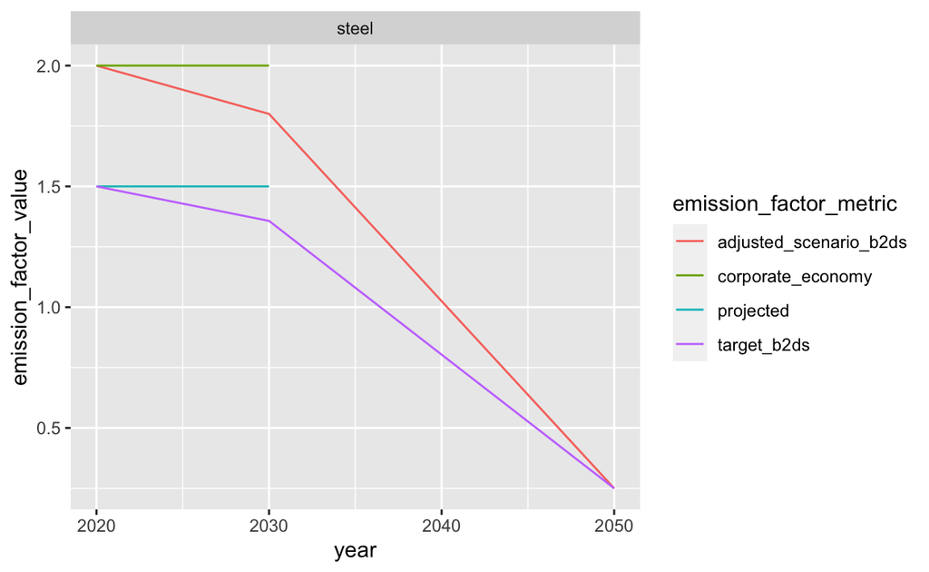

```
matched <- tibble::tribble(
  ~id_loan, ~loan_size_outstanding, ~loan_size_outstanding_currency, ~loan_size_credit_limit, ~loan_size_credit_limit_currency, ~id_2dii, ~level, ~score, ~sector, ~name_ald, ~sector_ald,
  "L1", 1, "EUR", 2, "EUR", "UP1", "ultimate_parent", 1, "steel", "company a", "steel"
)

# an ALD file with values only between 2020 and 2030
ald <- tibble::tribble(
  ~name_company, ~sector, ~technology, ~year, ~production, ~emission_factor, ~plant_location, ~is_ultimate_owner,
  "company a", "steel", "steel", 2020, 1, 1.5, "DE", TRUE,
  "company a", "steel", "steel", 2025, 1, 1.5, "DE", TRUE,
  "company a", "steel", "steel", 2030, 1, 1.5, "DE", TRUE,
  "company b", "steel", "steel", 2020, 1, 2.5, "DE", TRUE,
  "company b", "steel", "steel", 2025, 1, 2.5, "DE", TRUE,
  "company b", "steel", "steel", 2030, 1, 2.5, "DE", TRUE
)

# a scenario file with targets at 2050
co2_scenario <- tibble::tribble(
  ~scenario_source, ~scenario, ~sector, ~region, ~year, ~emission_factor, ~emission_factor_unit,
  "etp_2017", "b2ds", "steel", "global", 2020, 2, "tonnes of CO2 per tonne of steel",
  "etp_2017", "b2ds", "steel", "global", 2025, 1.9, "tonnes of CO2 per tonne of steel",
  "etp_2017", "b2ds", "steel", "global", 2030, 1.8, "tonnes of CO2 per tonne of steel",
  "etp_2017", "b2ds", "steel", "global", 2050, 0.25, "tonnes of CO2 per tonne of steel",
)

# SDA portfolio-level results
sda_targets <- target_sda(
  matched,
  ald,
  co2_scenario
)

ggplot(
  data = sda_targets,
  mapping = aes(
    x = year,
    y = emission_factor_value,
    color = emission_factor_metric
  )
) +
  geom_line() +
  facet_wrap(~sector)
```

## Acknowledgements

While this release includes commits from only a few of us (jdhoffa, maurolepore), it is thanks to feedback from our colleagues and users.

Comment on this article Share: